# Data Visualisation with ggplot2 - Project

# AfterWork Data Science: Data Visualisation with Python Project

## 1. Defining the Question

### a) Specifying the Data Analysis Question?

Number of canceeled bookings? What was the booking ratio between resort hotels and city hotels? What was the percentage of booking for each year? Which was the busiest month for hotels? Most guests came from which country? How long do most people stay in hotels? Which was the most booked accommodation type (Single, Couple, Family)?

### b) Defining the Metric for Success

The solutions to the following questions will help us answer our research question:

- When is the best time of year to book a hotel room?
- When is the optimal length of stay in order to get the best daily rate?
- How will you know if a hotel was likely to receive a disproportionately high number of special requests?

## 2. Reading the Data

```r
# Install and load TidyVerse
library(tidyverse)
# YOUR CODE GOES BELOW
#install.packages("reshape2")

# loading the package
library(tidyverse)
# Load the data below
# ---
# ---
dataset_url = "https://raw.githubusercontent.com/WKhisa/Data-Visualisation-with-ggplot2/main/hotel_bookings.csv"
# ---
# YOUR CODE GOES BELOW
bookings_df <- read.csv(dataset_url)
```

```r
head(bookings_df, 5)
```

|  | hotel | is_canceled | lead_time | arrival_date_year | arrival_date_month | arrival_date_week_number | arrival_date_day_of_month | stays_in_weekend_nights | stays_in_week_nights | adults | children | babies | meal | country | market_segment | distribution_channel | is_repeated_guest | previous_cancellations | previous_bookings_not_canceled | reserved_room_type | assigned_room_type | booking_changes | deposit_type | agent | company | days_in_waiting_list | customer_type | adr | required_car_parking_spaces | … |
| --- | --- | --- | --- | --- | --- | --- | --- | --- | --- | --- | --- | --- | --- | --- | --- | --- | --- | --- | --- | --- | --- | --- | --- | --- | --- | --- | --- | --- | --- | --- |
| 1 | Resort Hotel | 0 | 342 | 2015 | July | 27 | 1 | 0 | 0 | 2 | 0 | 0 | BB | PRT | Direct | Direct | 0 | 0 | 0 | C | C | 3 | No Deposit | NULL | NULL | 0 | Transient | 0 | 0 | … |
| 2 | Resort Hotel | 0 | 737 | 2015 | July | 27 | 1 | 0 | 0 | 2 | 0 | 0 | BB | PRT | Direct | Direct | 0 | 0 | 0 | C | C | 4 | No Deposit | NULL | NULL | 0 | Transient | 0 | 0 | … |
| 3 | Resort Hotel | 0 | 7 | 2015 | July | 27 | 1 | 0 | 1 | 1 | 0 | 0 | BB | GBR | Direct | Direct | 0 | 0 | 0 | A | C | 0 | No Deposit | NULL | NULL | 0 | Transient | 75 | 0 | … |
| 4 | Resort Hotel | 0 | 13 | 2015 | July | 27 | 1 | 0 | 1 | 1 | 0 | 0 | BB | GBR | Corporate | Corporate | 0 | 0 | 0 | A | A | 0 | No Deposit | 304 | NULL | 0 | Transient | 75 | 0 | … |
| 5 | Resort Hotel | 0 | 14 | 2015 | July | 27 | 1 | 0 | 2 | 2 | 0 | 0 | BB | GBR | Online TA | TA/TO | 0 | 0 | 0 | A | A | 0 | No Deposit | 240 | NULL | 0 | Transient | 98 | 0 | … |

```r
# Checking the last 5 rows of data
# ---
tail(bookings_df, 5)
```

|  | hotel | is_canceled | lead_time | arrival_date_year | arrival_date_month | arrival_date_week_number | arrival_date_day_of_month | stays_in_weekend_nights | stays_in_week_nights | adults | children | babies | meal | country | market_segment | distribution_channel | is_repeated_guest | previous_cancellations | previous_bookings_not_canceled | reserved_room_type | assigned_room_type | booking_changes | deposit_type | agent | company | days_in_waiting_list | customer_type | adr | required_car_parking_spaces | … |
| --- | --- | --- | --- | --- | --- | --- | --- | --- | --- | --- | --- | --- | --- | --- | --- | --- | --- | --- | --- | --- | --- | --- | --- | --- | --- | --- | --- | --- | --- | --- |
| 119386 | City Hotel | 0 | 23 | 2017 | August | 35 | 30 | 2 | 5 | 2 | 0 | 0 | BB | BEL | Offline TA/TO | TA/TO | 0 | 0 | 0 | A | A | 0 | No Deposit | 394 | NULL | 0 | Transient | 96.14 | 0 | … |
| 119387 | City Hotel | 0 | 102 | 2017 | August | 35 | 31 | 2 | 5 | 3 | 0 | 0 | BB | FRA | Online TA | TA/TO | 0 | 0 | 0 | E | E | 0 | No Deposit | 9 | NULL | 0 | Transient | 225.43 | 0 | … |
| 119388 | City Hotel | 0 | 34 | 2017 | August | 35 | 31 | 2 | 5 | 2 | 0 | 0 | BB | DEU | Online TA | TA/TO | 0 | 0 | 0 | D | D | 0 | No Deposit | 9 | NULL | 0 | Transient | 157.71 | 0 | … |
| 119389 | City Hotel | 0 | 109 | 2017 | August | 35 | 31 | 2 | 5 | 2 | 0 | 0 | BB | GBR | Online TA | TA/TO | 0 | 0 | 0 | A | A | 0 | No Deposit | 89 | NULL | 0 | Transient | 104.40 | 0 | … |
| 119390 | City Hotel | 0 | 205 | 2017 | August | 35 | 29 | 2 | 7 | 2 | 0 | 0 | HB | DEU | Online TA | TA/TO | 0 | 0 | 0 | A | A | 0 | No Deposit | 9 | NULL | 0 | Transient | 151.20 | 0 | … |

```r
# Sample 10 rows of data
# ---
# YOUR CODE GOES BELOW
#
sample_n(bookings_df, 10, replace = TRUE)
```

| hotel | is_canceled | lead_time | arrival_date_year | arrival_date_month | arrival_date_week_number | arrival_date_day_of_month | stays_in_weekend_nights | stays_in_week_nights | adults | children | babies | meal | country | market_segment | distribution_channel | is_repeated_guest | previous_cancellations | previous_bookings_not_canceled | reserved_room_type | assigned_room_type | booking_changes | deposit_type | agent | company | days_in_waiting_list | customer_type | adr | required_car_parking_spaces | total_of_special_requests | … |
| --- | --- | --- | --- | --- | --- | --- | --- | --- | --- | --- | --- | --- | --- | --- | --- | --- | --- | --- | --- | --- | --- | --- | --- | --- | --- | --- | --- | --- | --- | --- |
| City Hotel | 0 | 3 | 2016 | February | 9 | 21 | 2 | 0 | 2 | 0 | 0 | BB | NLD | Online TA | Direct | 0 | 0 | 0 | D | D | 0 | No Deposit | NULL | NULL | 0 | Transient | 105.00 | 0 | 0 | … |
| City Hotel | 1 | 27 | 2016 | May | 20 | 10 | 0 | 3 | 2 | 0 | 0 | BB | TJK | Online TA | TA/TO | 0 | 0 | 0 | A | A | 0 | No Deposit | 9 | NULL | 0 | Transient | 141.00 | 0 | 0 | … |
| City Hotel | 1 | 89 | 2015 | October | 40 | 3 | 2 | 2 | 2 | 0 | 0 | BB | PRT | Groups | TA/TO | 0 | 0 | 0 | A | A | 0 | Non Refund | 1 | NULL | 0 | Transient | 62.00 | 0 | 0 | … |
| Resort Hotel | 0 | 4 | 2016 | January | 4 | 17 | 2 | 4 | 2 | 0 | 0 | HB | PRT | Offline TA/TO | TA/TO | 0 | 0 | 0 | D | D | 1 | No Deposit | 314 | NULL | 0 | Transient | 69.00 | 1 | 1 | … |
| Resort Hotel | 1 | 4 | 2015 | October | 43 | 24 | 2 | 1 | 2 | 0 | 0 | BB | PRT | Direct | Direct | 0 | 0 | 0 | D | D | 0 | No Deposit | NULL | NULL | 0 | Transient | 45.00 | 0 | 0 | … |
| City Hotel | 1 | 28 | 2015 | August | 32 | 3 | 1 | 3 | 2 | 0 | 0 | BB | PRT | Groups | TA/TO | 0 | 0 | 0 | A | A | 0 | No Deposit | 1 | NULL | 0 | Transient-Party | 62.00 | 0 | 0 | … |
| Resort Hotel | 0 | 0 | 2017 | March | 13 | 28 | 0 | 1 | 1 | 0 | 0 | BB | PRT | Corporate | Corporate | 1 | 0 | 7 | A | A | 0 | No Deposit | NULL | 290 | 0 | Transient | 35.00 | 0 | 0 | … |
| City Hotel | 0 | 47 | 2015 | November | 46 | 11 | 0 | 3 | 2 | 0 | 0 | BB | FRA | Offline TA/TO | TA/TO | 0 | 0 | 0 | D | D | 0 | No Deposit | 28 | NULL | 0 | Transient | 60.00 | 0 | 0 | … |
| City Hotel | 0 | 142 | 2017 | April | 15 | 12 | 0 | 3 | 2 | 0 | 0 | BB | ESP | Online TA | TA/TO | 0 | 0 | 0 | A | A | 2 | No Deposit | 9 | NULL | 0 | Transient | 136.33 | 1 | 1 | … |
| City Hotel | 1 | 313 | 2017 | April | 17 | 29 | 2 | 1 | 2 | 0 | 0 | BB | PRT | Offline TA/TO | TA/TO | 0 | 0 | 0 | A | A | 0 | Non Refund | 6 | NULL | 0 | Transient | 90.00 | 0 | 0 | … |

```r
# Checking number of rows and columns
# ---
# YOUR CODE GOES BELOW
#
dim(bookings_df)
```

```
[1] 119390     32
```

```r
# Checking datatypes
# ---
# YOUR CODE GOES BELOW
#
str(bookings_df)
```

```
'data.frame':   119390 obs. of  32 variables:
 $ hotel                         : chr  "Resort Hotel" "Resort Hotel" "Resort Hotel" "Resort Hotel" ...
 $ is_canceled                   : int  0 0 0 0 0 0 0 0 1 1 ...
 $ lead_time                     : int  342 737 7 13 14 14 0 9 85 75 ...
 $ arrival_date_year             : int  2015 2015 2015 2015 2015 2015 2015 2015 2015 2015 ...
 $ arrival_date_month            : chr  "July" "July" "July" "July" ...
 $ arrival_date_week_number      : int  27 27 27 27 27 27 27 27 27 27 ...
 $ arrival_date_day_of_month     : int  1 1 1 1 1 1 1 1 1 1 ...
 $ stays_in_weekend_nights       : int  0 0 0 0 0 0 0 0 0 0 ...
 $ stays_in_week_nights          : int  0 0 1 1 2 2 2 2 3 3 ...
 $ adults                        : int  2 2 1 1 2 2 2 2 2 2 ...
 $ children                      : int  0 0 0 0 0 0 0 0 0 0 ...
 $ babies                        : int  0 0 0 0 0 0 0 0 0 0 ...
 $ meal                          : chr  "BB" "BB" "BB" "BB" ...
 $ country                       : chr  "PRT" "PRT" "GBR" "GBR" ...
```

[output cut: 18 more lines]

Record your general observations below:

Dataset has 119390 oservations and 32 features Dataset has mixed datatypes

## 3. External Data Source Validation

The data is originally from the article Hotel Booking Demand Datasets, by Nuno Antonio, Ana Almeida, and Luis Nunes for Data in Brief, Volume 22, February 2019.

## 4. Data Preparation

### Performing Data Cleaning

```r
# Checking datatypes and missing entries of all the variables
# ---
# YOUR CODE GOES BELOW
#
colSums(is.na(bookings_df))
```

```
                         hotel
                             0
                   is_canceled
                             0
                     lead_time
                             0
             arrival_date_year
                             0
            arrival_date_month
                             0
      arrival_date_week_number
                             0
     arrival_date_day_of_month
                             0
       stays_in_weekend_nights
                             0
          stays_in_week_nights
                             0
                        adults
                             0
                      children
                             4
                        babies
                             0
                          meal
                             0
                       country
                             0
                market_segment
                             0
          distribution_channel
                             0
             is_repeated_guest
                             0
        previous_cancellations
                             0
previous_bookings_not_canceled
                             0
            reserved_room_type
                             0
```

[output cut: 9 more lines]

```
                             0
          days_in_waiting_list
                             0
                 customer_type
                             0
                           adr
                             0
   required_car_parking_spaces
                             0
     total_of_special_requests
                             0
            reservation_status
                             0
       reservation_status_date
                             0
```

```r
# Checking how many duplicate rows are there in the data
# ---
# YOUR CODE GOES BELOW
#
bookings_df[duplicated(bookings_df), ]
```

|  | hotel | is_canceled | lead_time | arrival_date_year | arrival_date_month | arrival_date_week_number | arrival_date_day_of_month | stays_in_weekend_nights | stays_in_week_nights | adults | children | babies | meal | country | market_segment | distribution_channel | is_repeated_guest | previous_cancellations | previous_bookings_not_canceled | reserved_room_type | assigned_room_type | booking_changes | deposit_type | agent | company | days_in_waiting_list | customer_type | adr | required_car_parking_spaces | … |
| --- | --- | --- | --- | --- | --- | --- | --- | --- | --- | --- | --- | --- | --- | --- | --- | --- | --- | --- | --- | --- | --- | --- | --- | --- | --- | --- | --- | --- | --- | --- |
| 6 | Resort Hotel | 0 | 14 | 2015 | July | 27 | 1 | 0 | 2 | 2 | 0 | 0 | BB | GBR | Online TA | TA/TO | 0 | 0 | 0 | A | A | 0 | No Deposit | 240 | NULL | 0 | Transient | 98.00 | 0 | … |
| 23 | Resort Hotel | 0 | 72 | 2015 | July | 27 | 1 | 2 | 4 | 2 | 0 | 0 | BB | PRT | Direct | Direct | 0 | 0 | 0 | A | A | 1 | No Deposit | 250 | NULL | 0 | Transient | 84.67 | 0 | … |
| 44 | Resort Hotel | 0 | 70 | 2015 | July | 27 | 2 | 2 | 3 | 2 | 0 | 0 | HB | ROU | Direct | Direct | 0 | 0 | 0 | E | E | 0 | No Deposit | 250 | NULL | 0 | Transient | 137.00 | 0 | … |
| 139 | Resort Hotel | 1 | 5 | 2015 | July | 28 | 5 | 1 | 0 | 2 | 0 | 0 | BB | PRT | Online TA | TA/TO | 0 | 0 | 0 | D | D | 0 | No Deposit | 240 | NULL | 0 | Transient | 97.00 | 0 | … |
| 201 | Resort Hotel | 0 | 0 | 2015 | July | 28 | 7 | 0 | 1 | 1 | 0 | 0 | BB | GBR | Online TA | TA/TO | 0 | 0 | 0 | A | A | 0 | No Deposit | 240 | NULL | 0 | Transient | 109.80 | 0 | … |
| 220 | Resort Hotel | 1 | 1 | 2015 | July | 28 | 8 | 0 | 1 | 2 | 0 | 0 | BB | PRT | Corporate | Corporate | 0 | 0 | 0 | A | A | 0 | No Deposit | NULL | 110 | 0 | Transient | 104.72 | 0 | … |
| 257 | Resort Hotel | 0 | 91 | 2015 | July | 28 | 10 | 0 | 2 | 2 | 0 | 0 | BB | PRT | Online TA | TA/TO | 0 | 0 | 0 | A | A | 0 | No Deposit | 240 | NULL | 0 | Transient | 73.80 | 0 | … |
| 262 | Resort Hotel | 0 | 30 | 2015 | July | 28 | 10 | 2 | 2 | 2 | 0 | 0 | FB | PRT | Direct | Direct | 0 | 0 | 0 | F | F | 0 | No Deposit | NULL | NULL | 0 | Transient-Party | 197.00 | 0 | … |
| 354 | Resort Hotel | 0 | 98 | 2015 | July | 29 | 13 | 1 | 1 | 2 | 0 | 0 | BB | ESP | Online TA | TA/TO | 0 | 0 | 0 | A | A | 0 | No Deposit | 240 | NULL | 0 | Transient-Party | 82.00 | 0 | … |
| 373 | Resort Hotel | 0 | 40 | 2015 | July | 29 | 13 | 1 | 4 | 2 | 0 | 0 | BB | ESP | Direct | Direct | 0 | 0 | 0 | D | D | 0 | No Deposit | 250 | NULL | 0 | Transient | 120.00 | 0 | … |

[output cut: 990 more lines]

We choose to keep the duplicates because we don’t have a unique identifier to actually proof that we have duplicates.

```r
# Checking if any of the columns are all null
# ---
# YOUR CODE GOES BELOW
#
colSums(is.na(bookings_df))
```

```
                         hotel
                             0
                   is_canceled
                             0
                     lead_time
                             0
             arrival_date_year
                             0
            arrival_date_month
                             0
      arrival_date_week_number
                             0
     arrival_date_day_of_month
                             0
       stays_in_weekend_nights
                             0
          stays_in_week_nights
                             0
                        adults
                             0
                      children
                             4
                        babies
                             0
                          meal
                             0
                       country
                             0
                market_segment
                             0
          distribution_channel
                             0
             is_repeated_guest
                             0
        previous_cancellations
                             0
previous_bookings_not_canceled
                             0
            reserved_room_type
                             0
```

[output cut: 9 more lines]

```
                             0
          days_in_waiting_list
                             0
                 customer_type
                             0
                           adr
                             0
   required_car_parking_spaces
                             0
     total_of_special_requests
                             0
            reservation_status
                             0
       reservation_status_date
                             0
```

```r
# Checking if any of the rows are all null
# ---
# YOUR CODE GOES BELOW
#
is.null((bookings_df))
```

```
[1] FALSE
```

```r
# Checking the correlation of the features through the use of
# visualizations the correlation using heatmap
# ---
# YOUR CODE GOES BELOW
#
install.packages("reshape2")
# loading the package
library(reshape2)
# Select the desired columns
heatmap_df <- bookings_df %>%
  select(is_canceled, stays_in_weekend_nights, stays_in_week_nights, is_repeated_guest)

# Create a correlation matrix
corr_matrix <- cor(heatmap_df, method="s")
head(corr_matrix)
```

```
                         is_canceled
is_canceled              1.000000000
stays_in_weekend_nights -0.004105509
stays_in_week_nights     0.041417720
is_repeated_guest       -0.084793418
                        stays_in_weekend_nights
is_canceled                        -0.004105509
stays_in_weekend_nights             1.000000000
stays_in_week_nights                0.238053121
is_repeated_guest                  -0.097071678
                        stays_in_week_nights
is_canceled                       0.04141772
stays_in_weekend_nights           0.23805312
stays_in_week_nights              1.00000000
is_repeated_guest                -0.12839620
                        is_repeated_guest
is_canceled                   -0.08479342
stays_in_weekend_nights       -0.09707168
stays_in_week_nights          -0.12839620
is_repeated_guest              1.00000000
```

```r
# Create a table with long form
corr_df <- melt(corr_matrix)
head(corr_df)
```

|  | Var1 | Var2 | value |
| --- | --- | --- | --- |
| 1 | is_canceled | is_canceled | 1.000000000 |
| 2 | stays_in_weekend_nights | is_canceled | -0.004105509 |
| 3 | stays_in_week_nights | is_canceled | 0.041417720 |
| 4 | is_repeated_guest | is_canceled | -0.084793418 |
| 5 | is_canceled | stays_in_weekend_nights | -0.004105509 |
| 6 | stays_in_weekend_nights | stays_in_weekend_nights | 1.000000000 |

[figure not shown]

```r
# Plot the heatmap
ggplot(corr_df, aes(Var1, Var2, fill = value)) +
  geom_tile(color = "black") +
  geom_text(
    aes(label = round(value, 2)),
    color = "white"
  ) +
  coord_fixed() +
  labs(
    fill="Pearson Correlation"
  ) +
  scale_fill_gradient2(
    low = "blue",
    high = "red",
    mid = "white",
    limit = c(-1,1)
  ) +
  theme(
    axis.title.x = element_blank(),
    axis.title.y = element_blank()
  )
```

```r
# Dropping company column because it has alot of missing values
# and we won't need to answer any of our questions
# ---
# YOUR CODE GOES BELOW
#
bookings_df <- select(bookings_df, -c("company"))
```

From the data variable description we see that the Distribution Channel categoricy that tells us about Booking distribution.

The term “TA” means “Travel Agents” The term “TO” means “Tour Operators” This allows us to fill the missing values in the agents column with TO

```r
# We replace the mising values i.e. for TO
# ---
# YOUR GOES BELOW
#
bookings_df$agent[is.na(bookings_df$agent)] <- "TO"
```

```r
# We drop rows where there is no adult, baby and child as
# these records won't help us.
# ---
# YOUR GOES BELOW
#
bookings_df <- bookings_df[!(bookings_df$adults == 0 | bookings_df$babies == 0 | bookings_df$children == 0),]
```

```r
# We replace missing children values with rounded mean value
# ---
# Hint i.e. use round()
# ---
# YOUR GOES BELOW
#
rounded_mean <- round(mean(bookings_df$children, na.rm = TRUE))
rounded_mean
```

```
[1] 1
```

```r
bookings_df$children[is.na(bookings_df$children)] <- rounded_mean
```

```r
# Checking for missing values in the dataframe
# ---
# YOUR GOES BELOW
#
colSums(is.na(bookings_df))
```

```
                         hotel
                             0
                   is_canceled
                             0
                     lead_time
                             0
             arrival_date_year
                             0
            arrival_date_month
                             0
      arrival_date_week_number
                             0
     arrival_date_day_of_month
                             0
       stays_in_weekend_nights
                             0
          stays_in_week_nights
                             0
                        adults
                             0
                      children
                             0
                        babies
                             0
                          meal
                             0
                       country
                             0
                market_segment
                             0
          distribution_channel
                             0
             is_repeated_guest
                             0
        previous_cancellations
                             0
previous_bookings_not_canceled
                             0
            reserved_room_type
                             0
            assigned_room_type
                             0
               booking_changes
                             0
                  deposit_type
                             0
                         agent
                             0
          days_in_waiting_list
                             0
                 customer_type
                             0
                           adr
                             0
   required_car_parking_spaces
                             0
     total_of_special_requests
                             0
            reservation_status
                             0
       reservation_status_date
                             0
```

```r
# Converting the datatypes of the following columns from float to integer
# i.e. children, company, agent
# ---
# YOUR GOES BELOW
#
bookings_df <- bookings_df %>%
  transform(children = as.integer(children), agent = as.integer(agent))
#is.na(bookings_df$children)
#str(bookings_df)
#is.na(bookings_df$agent)
```

## 5. Solution Implementation

### 5.a) Questions

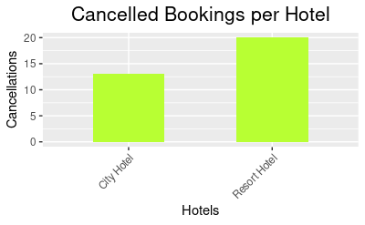

```r
# 1. How many bookings were cancelled?
# ---
# Visualisation: Barplot

cancelled_df <- bookings_df %>%
  filter(is_canceled == 1) %>%
  count(hotel, is_canceled, sort = TRUE, name = "Count")

# Plotting the chart
ggplot(cancelled_df, aes(x = hotel, y = Count)) +
  geom_col(
    stat="identity", width=0.5, fill = "#b8ff33"
  )  +
  labs(
    title = "Cancelled Bookings per Hotel",
    x = "Hotels",
    y = "Cancellations"
  ) +
  theme(
    plot.title = element_text(hjust = 0.5, size=16),
    axis.text.x = element_text(angle = 45, hjust = 1)
  )
```

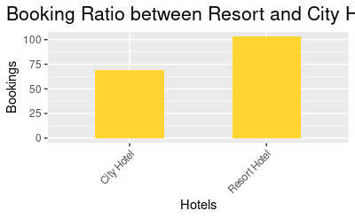

```r
# 2. What was the booking ratio between resort hotel and city hotel?
# ---
# Barplot of booking ratio between resort hotel and city hotel
ratio_df <- bookings_df %>%
  count(hotel, is_canceled, sort = TRUE, name = "Count")

# Plotting the chart
ggplot(ratio_df, aes(x = hotel, y = Count)) +
  geom_col(
    stat="identity", width=0.5, fill = "#ffd433"
  )  +
  labs(
    title = "Booking Ratio between Resort and City Hotel",
    x = "Hotels",
    y = "Bookings"
  ) +
  theme(
    plot.title = element_text(hjust = 0.5, size=16),
    axis.text.x = element_text(angle = 45, hjust = 1)
  )
```

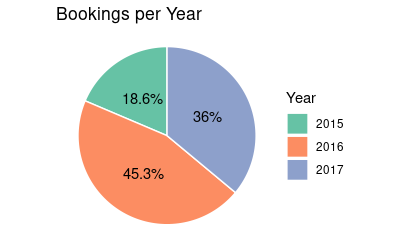

```r
# 3. What was the percentage of booking for each year?
# ---
piechart_df <- bookings_df %>%
  group_by(arrival_date_year) %>%
  summarise(bookings=n())

piechart_df$arrival_date_year <- as.character(piechart_df$arrival_date_year)


# Plotting the chart
ggplot(data=piechart_df, aes(x="", y=bookings, fill=arrival_date_year)) +
  geom_bar(
    stat="identity", width=0.5, color = "white"
  ) +
  coord_polar("y") +
  geom_text(
    aes(label = paste0(round(bookings / sum(bookings) * 100, 1), "%")), position = position_stack(vjust = 0.5)
  ) +
  scale_fill_brewer(palette="Set2") +
  labs(
    fill = "Year",
    title = "Bookings per Year"
  ) +
  theme_void()
```

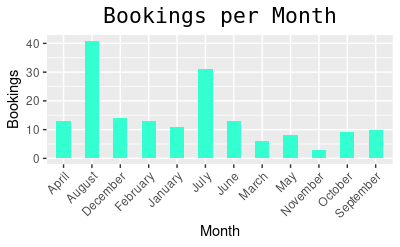

```r
# 4. Which were the most busiest months for hotels?
# ---
#
months_df <- bookings_df %>%
  group_by(arrival_date_month) %>%
  summarise(bookings=n()) %>%
  arrange(desc(bookings))

ggplot(months_df, aes(x = arrival_date_month, y = bookings)) +
  geom_col(
    stat="identity", width=0.5, fill = "#33ffd1"
  )  +
  labs(
    title = "Bookings per Month",
    x = "Month",
    y = "Bookings"
  ) +
  theme(
    plot.title = element_text(hjust = 0.5, size=16, family="Mono"),
    axis.text.x = element_text(angle = 45, hjust = 1)
  )
```

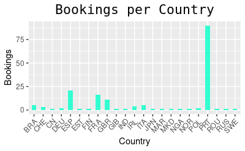

```r
# 5. From which top 3 countries did most guests come from?
# ---
# YOUR GOES BELOW
#
top_countries_df <- bookings_df %>%
  group_by(country) %>%
  summarise(bookings=n()) %>%
  arrange(desc(bookings))

ggplot(top_countries_df, aes(x = country, y = bookings)) +
  geom_col(
    stat="identity", width=0.5, fill = "#33ffd1"
  )  +
  labs(
    title = "Bookings per Country",
    x = "Country",
    y = "Bookings"
  ) +
  theme(
    plot.title = element_text(hjust = 0.5, size=16, family="Mono"),
    axis.text.x = element_text(angle = 45, hjust = 1)
  )
```

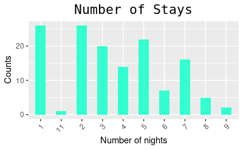

```r
# 6.a) How long do most people stay in hotels?
#   b) By city and resort? Separate the data by hotel
# ---
#
total_stay_df <- bookings_df %>%
  filter(is_canceled == 0) %>%
  mutate(total_nights = rowSums(across(c(stays_in_weekend_nights,stays_in_week_nights)))) %>%
  group_by(total_nights) %>%
  summarise(counts=n()) %>%
  arrange(desc(counts))

total_stay_df$total_nights <- as.character(total_stay_df$total_nights)

# Plotting the chart
ggplot(total_stay_df, aes(x = total_nights, y = counts)) +
  geom_col(
    stat="identity", width=0.5, fill = "#33ffd1"
  )  +
  labs(
    title = "Number of Stays",
    x = "Number of nights",
    y = "Counts"
  ) +
  theme(
    plot.title = element_text(hjust = 0.5, size=16, family="Mono"),
    axis.text.x = element_text(angle = 45, hjust = 1)
  )
```

```r
# 7. Which was the most booked accommodation type (Single, Couple, Family)?
# ---
#
singles_df <- bookings_df %>%
  filter(is_canceled == 0, adults == 1, children == 0, babies ==0) %>%
  group_by(country) %>%
  summarise(bookings=n()) %>%
  arrange(desc(bookings))

couples_df <- bookings_df %>%
  filter(is_canceled == 0, adults == 2, children == 0, babies ==0) %>%
  group_by(country) %>%
  summarise(bookings=n()) %>%
  arrange(desc(bookings))

families_df <- bookings_df %>%
  filter(is_canceled == 0, adults == 1, children == 0, babies ==0) %>%
  group_by(country) %>%
  summarise(bookings=n()) %>%
  arrange(desc(bookings))
```

## 6. Challenging your Solution

In this step, we review our solution and implement approaches that could potentially provide a better outcome. In our case, we could propose the following question that wasn’t answered in our solution because it couldn’t have greatly contributed to our recommendation.

```r
# When should hotels provide special offers?
# ---
# YOUR GOES BELOW
#
```

## 7. Follow up questions

During this step, you rethink and propose other ways that you can improve your solution.

a). Did we have the right data? b). Do we need other data to answer our question? c). Did we have the right question?